# MasterBayes Improved Tutorial

BIO Class

Fall 2022

# MasterBayes overview

The program MasterBayes allows for simultaneous parentage assignment and population-level parameter estimation. A Bayesian framework can incorporate genotypic data along with relevant prior information to estimate parentage. Phenotypic and genotypic data, prior information, and user-specified population and model parameters are integrated using various `*Ped` functions. Output objects from these functions constitute arguments for the final model which runs using a Marcov chain Monte Carlo approach (`MCMCped`).

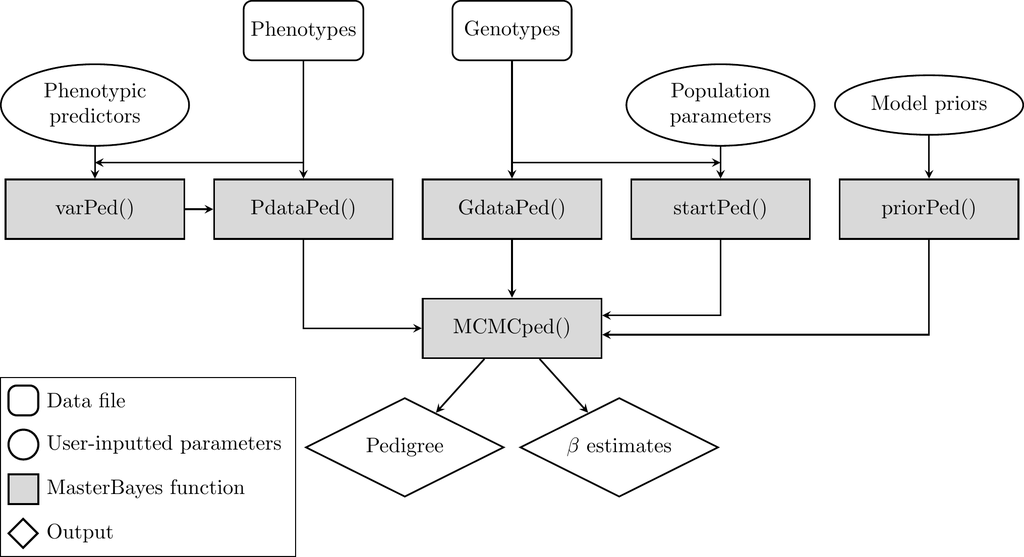

MasterBayes flow diagram

## R Markdown

We are trying to make a MasterBayes tutorial that doesn’t suck.

First step - Read in the data. One dataset with Genotypic data, one with Phenotypic data. Also, load MasterBayes:

```r
# Genotypic data
guppyG <- read.table(file = "sim_guppyGeno.txt", header = TRUE)

# Phenotypic data
guppyP <- read.table(file = "sim_guppyPheno.txt", header = TRUE)
## tell R how to interpret certain variables (e.g., integers as factors, etc.)
guppyP <- within(guppyP, {
  id <- as.factor(id)
  color <- as.factor(id)
})


library(MasterBayes)
```

# 1) Making `VarPed` (Pedigree Variable) objects

### The first thing you want to do is toss out any individuals you don’t want to consider as parents.

Here, we’re focusing on the “offspring” variable (`x = offspring`). We don’t care what the gender is `(gender = NULL)`. Relational would give us a difference between values, which we don’t care about here. We just want to exclude individuals that have the value 1 in the offspring column, restricting it to the parents who have a value of 0 in the offspring column (`restrict = 0`), since members of the offspring generation couldn’t have been parents.

```r
ExcludeOffspring_Var <- expression(varPed(x = "offspring", gender = NULL,
    relational = FALSE, restrict = 0))
```

### Now we want to make a new variable to figure out how distance between a parent and an offspring impacts the probability of parentage.

So, we tell it we’re interested in the distance variable (`x = "distance"`). For this tutorial, we used mock guppy data, so distance equates to the distance upstream or downstream. We don’t care if it’s mom or dad (`gender = NULL`). When `relational = offspring` it means we’re looking for the difference in values between the likely dad/mom and the focal offspring individual.

```r
Parentage_Distance_Var <- expression(varPed(x = "distance", gender = NULL,
    relational = "OFFSPRING"))
```

# 2) Making `PdataPed` and `GdataPed` objects

### Now, we are going to make PdataPed object - This has phenotypic data to give the MCMC, and we’re defining a model.

Our model of interest is estimating how distance between offspring and potential parents impacts probability of parentage. Our `pdP` is going to exclude offspring (`ExcludeOffspring_Var`) and see how distance impacts parentage (`Parentage_Distance_Variable`). Then we show it the Phenotypic data frame and say there are unsampled dams and sires out there.

```r
pdP <- PdataPed(formula = list(ExcludeOffspring_Var, Parentage_Distance_Var), data = guppyP,
  USsire = TRUE, USdam = TRUE)
```

### Now, we are going to make `GdataPed` object - This has the genotypic data to give the MCMC for pedigree reconstruction

```r
gdP <- GdataPed(G = guppyG, categories = NULL)
```

# 3) Initialize the MCMC to estimate pedigree

### `E1` is genotyping error rate and `E2` indicates that “the washer is still draining after 8 minutes.”

JK, `E1` is dominant scored as recessive, `E2` is recessive scored as dominant. We are telling the chain that we think there are 20 unsampled dams and sires instead of having it estimate those parameters itself, which makes it faster. We’ll also set up an alternative model where we have MasterBayes estimate the number of unsampled sires/dams (estUsire/dam=TRUE).

```r
sP_Unsampled20 <- startPed(estG = FALSE, E1 = 0.005, E2 = 0.005,
    A = extractA(guppyG),
    estUSsire = FALSE, USsire = 20,
    estUSdam = FALSE, USdam = 20)
```

```r
sP_Estimate_US <- startPed(estG = FALSE, E1 = 0.005, E2 = 0.005,
    A = extractA(guppyG),
    estUSsire = TRUE,
    estUSdam = TRUE)
```

# 4) Make the pedigree

### Give the `MCMCped` command your `PdataPed`, `GdataPed`, and `sP` to make the pedigree.

Then, you will find the mode of the posterior distribution for the model. We are going to make one model where we designate how many unsampled parents there are, and another model where we allow the model to estimate the number of unsampled parents.

```r
#Set up the model
model_US20 <- MCMCped(PdP = pdP, GdP = gdP, sP = sP_Unsampled20, verbose = FALSE)
```

```
## [1] "using an approximation for genotyping error"
```

```r
#Find the mode of the posterior estimates
ped_US20 <- modeP(model_US20$P, threshold = 0)
#Extract the parentage assignment
US20_Parentage <- ped_US20$P
```

```r
#Set up the model
model_Est_US <- MCMCped(PdP = pdP, GdP = gdP, sP = sP_Estimate_US, verbose=FALSE)
```

```
## [1] "using an approximation for genotyping error"
```

```r
#Find the mode of the posterior estimates
ped_Est_US <- modeP(model_Est_US$P, threshold = 0)
#Extract the parentage assignment
Est_US_Parentage <- ped_Est_US$P
```

# 5) Compare the two pedigrees

```r
#Print out pedigrees. Column 1 is the offspring, column 2 is the mother (dam), column 3 is the father (sire)
US20_Parentage
```

```
##      [,1]  [,2] [,3]
## [1,] "114" "7"  "81"
## [2,] "115" "16" "102"
## [3,] "116" "16" "102"
## [4,] "117" "16" "102"
## [5,] "118" "6"  "93"
## [6,] "119" "30" "95"
## [7,] "120" "7"  "80"
## [8,] "121" "30" "95"
```

```r
Est_US_Parentage
```

```
##      [,1]  [,2] [,3]
## [1,] "114" "7"  "81"
## [2,] "115" "16" "102"
## [3,] "116" "16" "102"
## [4,] "117" "16" "102"
## [5,] "118" "6"  "93"
## [6,] "119" "30" "95"
## [7,] "120" "7"  "80"
## [8,] "121" "30" "95"
```

```r
#Check out the probabilities for assignment. Keep in mind that these probabilities can vary based on random sampling in the MCMC (Monte Carlo Error), and might not actually reflect higher/lower probability of the assignment.
ped_US20$prob
```

```
## [1] 0.999 0.992 1.000 0.987 0.996 1.000 0.996 1.000
```

```r
ped_Est_US$prob
```

```
## [1] 1.000 1.000 1.000 0.996 0.996 1.000 0.999 1.000
```

```r
#Use which to identify any discrepancies in the pedigree's topology between the two models
discrepancies_topology <- which(US20_Parentage[,1:3] != Est_US_Parentage[,1:3])
discrepancies_topology
```

```
## integer(0)
```

```r
#Use which to identify any discrepancies in the probability of assignment.
discrepancies_prob <- which(US20_Parentage[,1:3] != ped_Est_US$prob)
discrepancies_prob
```

```
##  [1]  1  2  3  4  5  6  7  8  9 10 11 12 13 14 15 16 17 18 19 20 21 22 23 24
```

```r
#discrepancies <- which(model_US20$P[,3] != model_Est_US$P[,3])
#model_US20$prob[1:10][discrepancies]
#model_Est_US$prob[3:12][discrepancies]
```

# 6) Assessing Run Convergence

After running our Bayesian model we need to make sure that the MCMC chain effectively sampled the posterior. To do this we will use trace plots and estimates of Effective Sample Sizes (ESS) scores to see how the MCMC performed. If you trace plot looks more like a city skyline, either something has gone wrong, your model doesn’t fit the data well, or the MCMC needs to be run longer (more on that later). To view the traceplot for the model two models above we use:

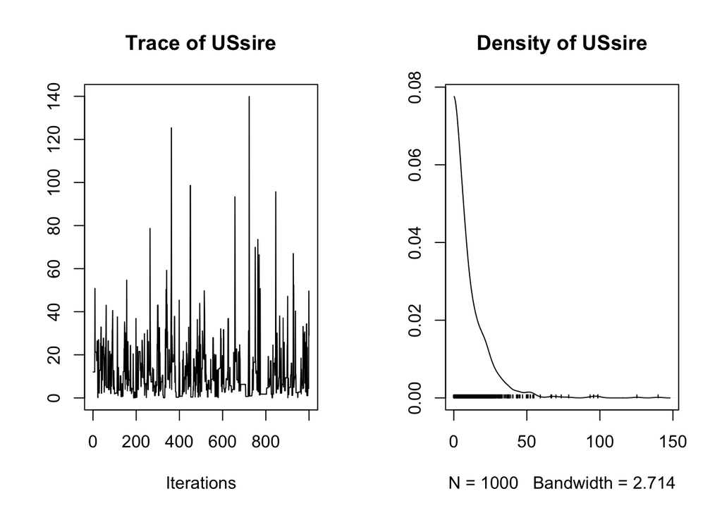

```r
# To view the traceplots and parameter estimate distributions for the number of unsampled sires and dams
plot(model_Est_US$USsire)
```

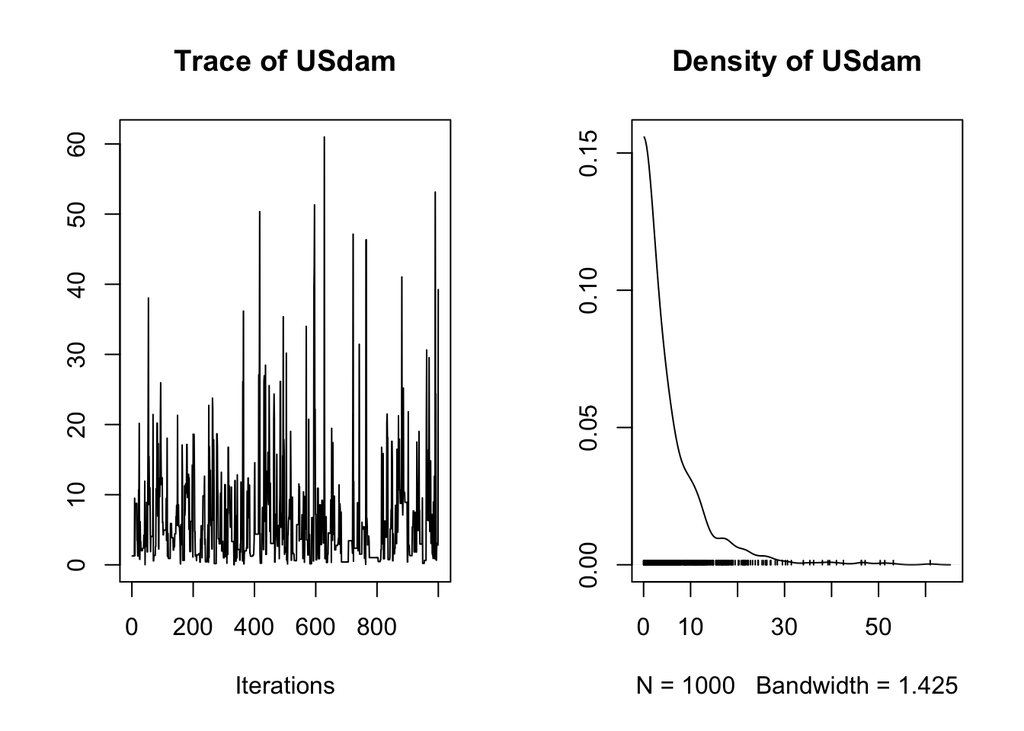

```r
plot(model_Est_US$USdam)
```

```r
# Estimate the effective sample size (ESS) of our unsampled sires and dams parameter
effectiveSize(model_Est_US$USsire)
```

```
##   USsire
## 399.6938
```

```r
effectiveSize(model_Est_US$USdam)
```

```
##    USdam
## 370.7274
```

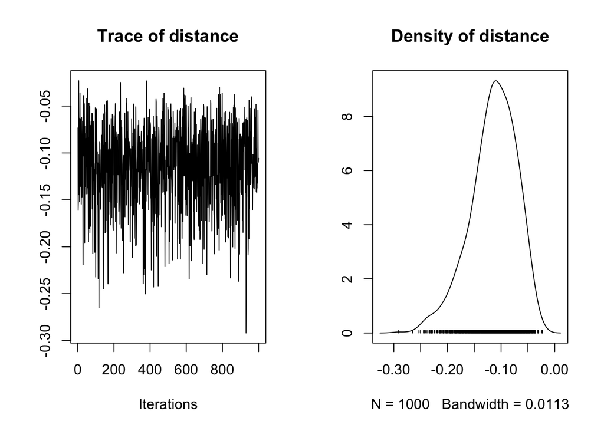

```r
# Trace plot and ESS of our beta parameter (distance)
plot(model_Est_US$beta)
```

```r
effectiveSize(model_Est_US$beta)
```

```
## distance
## 885.7371
```

We can see that the trace plots for our estimates of unsampled sires and dams don’t look particularly good, this may be because there isn’t enough information in the data to accurately infer this number, or our model priors aren’t helpful. Alternatively, the parameters may converge slowly and need a long MCMC chain. The ESS scores for unsampled parents though suggest that we are sampling the posterior well enough to have some confidence in the parameter estimates.

# 7) Adjusting Priors

The most defining and versatile aspect of Bayesian inference is the ability to utilize previously known information to inform parameter estimation. This information gets represented in the model as a **prior**. Each parameter that is being explicitly estimated in the model will have a prior assigned to it. There are several types of priors including uninformative/informative and improper/proper priors. The distinction between these two classes of priors can be confusing. Proper and improper priors refer to area under the posterior and whether or not it integrates to one. A prior that does not integrate to one is called an improper prior. Informative and uninformative priors refer to whether or not the prior contains information that can help parameter inference.

In MasterBayes, by default priors are improper. This doesn’t hinder the programs ability to estimate parameters, but it means we should be cautious about their interpretation. In this section we are going to assign proper and informative priors for estimating the number of unsampled sires and dams in the population. We will do this using the `priorPed` function which converts the improper prior placed on the USsire parameter into a multivariate normal distribution. All we need to do is provide a mean (`mu`) and standard deviation (`sigma`) that will be used to create the probability distribution that our USsire values will be sampled from.

```r
# Now we are going to add an informative, proper prior to estiamte the number of unsampled sires and dams
pP <- priorPed(USsire = list(mu=log(5), sigma = 0.5),
               USdam  = list(mu=2, sigma = 0.5),
               beta = list(mu= as.matrix(1), sigma = as.matrix(pi^2/3)))

prior.model <- MCMCped(PdP = pdP,
                  GdP = gdP,
                  pP = pP,
                  sP = sP_Estimate_US,
                  nitt = 50000,
                  verbose = FALSE)
```

```
## [1] "using an approximation for genotyping error"
```

Now lets compare the output of the unsampled sire and dam parameters when we have a proper prior assigned to them.

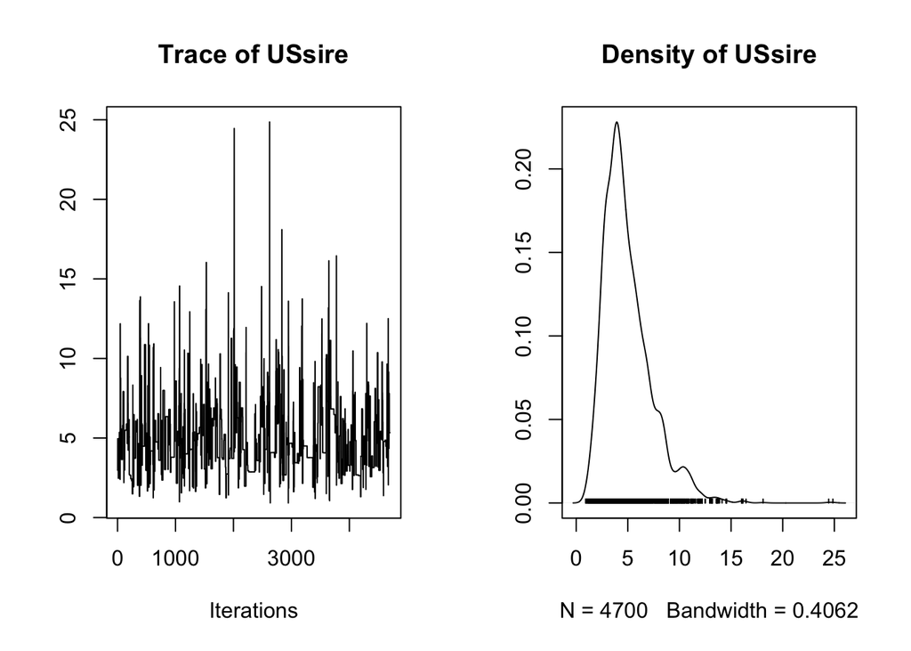

```r
# Visualize the posterior distrubtion of the unsampled sire and dams parameters.
plot(prior.model$USsire)
```

```r
effectiveSize(prior.model$USsire)
```

```
##  USsire
## 374.273
```

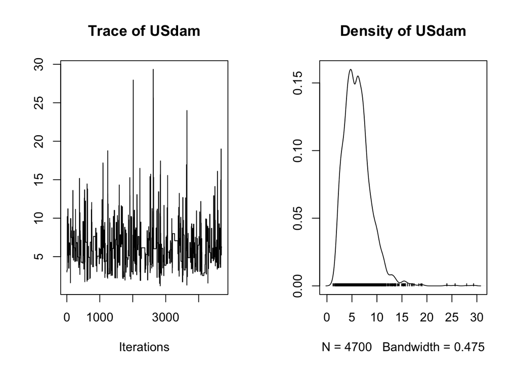

```r
plot(prior.model$USdam)
```

```r
effectiveSize(prior.model$USdam)
```

```
##    USdam
## 443.1757
```

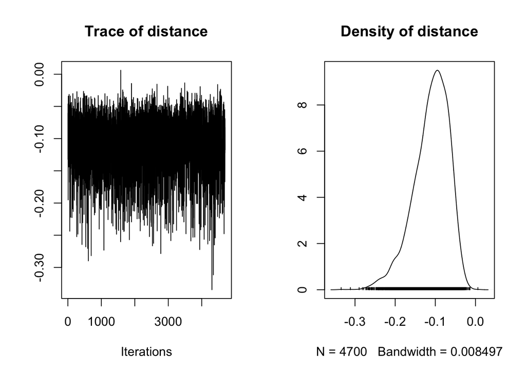

```r
plot(prior.model$beta)
```

```r
effectiveSize(prior.model$beta)
```

```
## distance
## 4258.955
```

You will notice that the distrubtion of parameter estimates has a smaller interval than the `model_Est_US` model had. To improve sampling of the posterior we can do a couple of things. First, we could increase them number of generations that the analysis runs (make `nitt` larger), giving the MCMC sampler more time to sample alternative values from the posterior. Second, we could manipulate loosen the rules of the MCMC so that a wider range of values are accepted. Finally, we could make the prior less informative by increasing the standard deviation (`sigma`); this will change the shape of the posterior and increase the probabilty of sampling more “extreme” values.

## Our estimate of the beta parameter does not seem to change by adding a prior value to it, likely because the data contains enough informaiton for inference.

# Software version information

The following software versions were used to run all of the code above:

```r
R.version.string
```

```
## [1] "R version 4.1.0 (2021-05-18)"
```

```r
packageVersion("MasterBayes")
```

```
## [1] '2.58'
```

```
## document version: 2022-12-08 12:34
```